# Reasoning_initial analysis

Andrew Stewart

5/26/2017

## Initial analysis regardless of endorsement. Total of 40 participants.

This is a 2 x 2 LMM with factors Validity (Valid vs Invalid) and Major Premise (Conditional vs Non-conditional).

Create a modified verion of the add_conditions function.

```r
add_conditions <- function(data) {
  data$CondType <- factor(data$CondType, levels = c("MP", "AC", "MPF", "ACF", "CB", "DB", "CF", "DF"))
  data$inference <- car::recode(data$CondType,
                                "c('MP', 'MPF')='MP';
                                c('AC', 'ACF')='AC';
                                c('CB', 'CF')='conj';
                                c('DB', 'DF')='disj'",
                                levels = c("MP", "AC", "conj", "disj"))
  data$polarity_premise <- car::recode(data$CondType,
                                       "c('MP', 'AC', 'CB', 'DB')='positive';
                                       c('MPF', 'ACF', 'CF', 'DF')='negative'",
                                       levels = c("positive", "negative"))
  data$validity <- factor(ifelse(data$CondType %in% c("MP", "CB", "DF"), "valid",
                                 ifelse(data$CondType %in% c("AC", "ACF", "DB", "CF"), "possible",
                                        "impossible")),
                          levels = c("valid", "possible", "impossible"))
  data$quasi_validity <- car::recode(data$CondType,
                                     "c('MP',  'CB', 'DF')='quasi_valid';
                                     c('MPF', 'AC', 'CF', 'DB')='quasi_invalid'",
                                     levels = c("quasi_valid", "quasi_invalid"))
  data$major_premise <- factor(ifelse(data$CondType %in% c("MP", "AC", "MPF", "ACF"), "conditional", "conjunction-disjunction"), levels = c( "conditional", "conjunction-disjunction"))
  data
}
```

Run the first pass analysis. First some data wrangling and setting up the contrasts.

```r
d_fp <- read_csv("~/Desktop/Air Work/R analyses/Reasoning/FP.csv")
d_fp <- add_conditions(d_fp)
attr(d_fp, "spec") <- NULL
str(d_fp)

index <- d_fp$CondType == "MP" | d_fp$CondType == "AC" | d_fp$CondType == "CB"| d_fp$CondType == "DB"
d_fp <- d_fp[index,]

d_fp$P.s <- as.factor (d_fp$P.s)
d_fp$Item <- as.factor (d_fp$Item)

contrasts (d_fp$quasi_validity) <- matrix (c(.5, -.5))
contrasts (d_fp$major_premise) <- matrix (c(.5, -.5))
```

Plot the means for each of the 4 conditions.

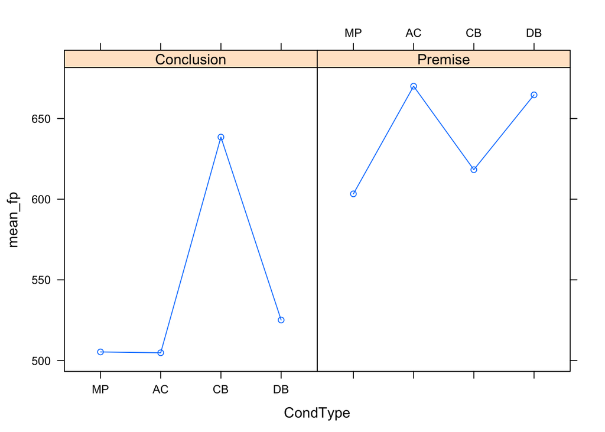

```r
d_fp_a <- d_fp %>%
  gather("dv", "rt", Premise:Conclusion) %>%
  group_by(CondType, dv) %>%
  summarise(mean_fp = mean(rt, na.rm = TRUE))

xyplot(mean_fp ~ CondType|dv, d_fp_a, type = "o")
```

There is a marginal effect of validity (p = .076) on first pass times to the minor premise with slower reading time in invalid than in valid conditions , but nothing on first pass times to the conclusion.

```r
#build the LMM for first pass times on the minor premise
modelfp_premise <- lmer (Premise ~ quasi_validity*major_premise + (1 + quasi_validity*major_premise| P.s)  + (1 + quasi_validity*major_premise| Item), data = d_fp, REML=TRUE)
summary (modelfp_premise)
```

```
## Linear mixed model fit by REML t-tests use Satterthwaite approximations
##   to degrees of freedom [lmerMod]
## Formula: Premise ~ quasi_validity * major_premise + (1 + quasi_validity *
##     major_premise | P.s) + (1 + quasi_validity * major_premise |
##     Item)
##    Data: d_fp
##
## REML criterion at convergence: 8921.8
##
## Scaled residuals:
##     Min      1Q  Median      3Q     Max
## -2.1253 -0.5135 -0.1582  0.3676  6.7633
##
## Random effects:
##  Groups   Name                           Variance Std.Dev. Corr
##  P.s      (Intercept)                     28572.3 169.03
##           quasi_validity1                  4832.4  69.52    0.40
##           major_premise1                   1609.0  40.11   -0.10 -0.95
##           quasi_validity1:major_premise1   1665.9  40.82   -0.96 -0.11
##  Item     (Intercept)                       670.0  25.88
##           quasi_validity1                  3123.1  55.88   -0.43
##           major_premise1                    384.8  19.62   -0.58  0.91
##           quasi_validity1:major_premise1  53708.1 231.75    0.87 -0.01
##  Residual                                109890.5 331.50
##
##
##
##
##  -0.19
##
##
##
##  -0.10
##
## Number of obs: 614, groups:  P.s, 40; Item, 32
##
## Fixed effects:
##                                Estimate Std. Error     df t value Pr(>|t|)
## (Intercept)                      636.74      30.26  38.97  21.043   <2e-16
## quasi_validity1                  -56.82      30.62  22.63  -1.856   0.0766
## major_premise1                    -4.87      27.78  80.35  -0.175   0.8613
## quasi_validity1:major_premise1   -18.38      67.80  26.68  -0.271   0.7885
##
## (Intercept)                    ***
## quasi_validity1                .
## major_premise1
## quasi_validity1:major_premise1
## ---
## Signif. codes:  0 '***' 0.001 '**' 0.01 '*' 0.05 '.' 0.1 ' ' 1
##
## Correlation of Fixed Effects:
##             (Intr) qs_vl1 mjr_p1
## quas_vldty1  0.105
## major_prms1 -0.030 -0.054
## qs_vldt1:_1 -0.007 -0.003 -0.012
```

```r
#build the LMM for first pass times on the conclusion
modelfp_concl <- lmer (Conclusion ~ quasi_validity*major_premise + (1 + quasi_validity*major_premise| P.s)  + (1 + quasi_validity*major_premise| Item), data = d_fp, REML=TRUE)
summary (modelfp_concl)
```

```
## Linear mixed model fit by REML t-tests use Satterthwaite approximations
##   to degrees of freedom [lmerMod]
## Formula:
## Conclusion ~ quasi_validity * major_premise + (1 + quasi_validity *
##     major_premise | P.s) + (1 + quasi_validity * major_premise |
##     Item)
##    Data: d_fp
##
## REML criterion at convergence: 9352.2
##
## Scaled residuals:
##     Min      1Q  Median      3Q     Max
## -3.5300 -0.4118 -0.1266  0.3015 15.5042
##
## Random effects:
##  Groups   Name                           Variance Std.Dev. Corr
##  P.s      (Intercept)                     26109   161.58
##           quasi_validity1                 18920   137.55    0.82
##           major_premise1                  57330   239.44   -0.93 -0.98
##           quasi_validity1:major_premise1  76057   275.78   -0.87 -1.00
##  Item     (Intercept)                      7386    85.94
##           quasi_validity1                 24739   157.29    1.00
##           major_premise1                  16644   129.01   -1.00 -1.00
##           quasi_validity1:major_premise1 100228   316.59   -1.00 -1.00
##  Residual                                209393   457.60
##
##
##
##
##   0.99
##
##
##
##   1.00
##
## Number of obs: 616, groups:  P.s, 40; Item, 32
##
## Fixed effects:
##                                Estimate Std. Error      df t value
## (Intercept)                      540.17      35.00   43.15  15.434
## quasi_validity1                   53.05      51.10   42.01   1.038
## major_premise1                   -71.68      57.60   45.64  -1.244
## quasi_validity1:major_premise1  -105.50     102.43   44.86  -1.030
##                                Pr(>|t|)
## (Intercept)                      <2e-16 ***
## quasi_validity1                   0.305
## major_premise1                    0.220
## quasi_validity1:major_premise1    0.309
## ---
## Signif. codes:  0 '***' 0.001 '**' 0.01 '*' 0.05 '.' 0.1 ' ' 1
##
## Correlation of Fixed Effects:
##             (Intr) qs_vl1 mjr_p1
## quas_vldty1  0.487
## major_prms1 -0.618 -0.492
## qs_vldt1:_1 -0.512 -0.479  0.489
```

Run the regression path analysis. First some data wrangling and setting up the contrasts.

```r
d_rp <- read_csv("~/Desktop/Air Work/R analyses/Reasoning/RP.csv")
d_rp <- add_conditions(d_rp)
attr(d_rp, "spec") <- NULL
str(d_rp)

index <- d_rp$CondType == "MP" | d_rp$CondType == "AC" | d_rp$CondType == "CB"| d_rp$CondType == "DB"
d_rp <- d_rp[index,]

d_rp$P.s <- as.factor (d_rp$P.s)
d_rp$Item <- as.factor (d_rp$Item)

contrasts (d_rp$quasi_validity) <- matrix (c(.5, -.5))
contrasts (d_rp$major_premise) <- matrix (c(.5, -.5))
```

Plot the means for each of the 4 conditions.

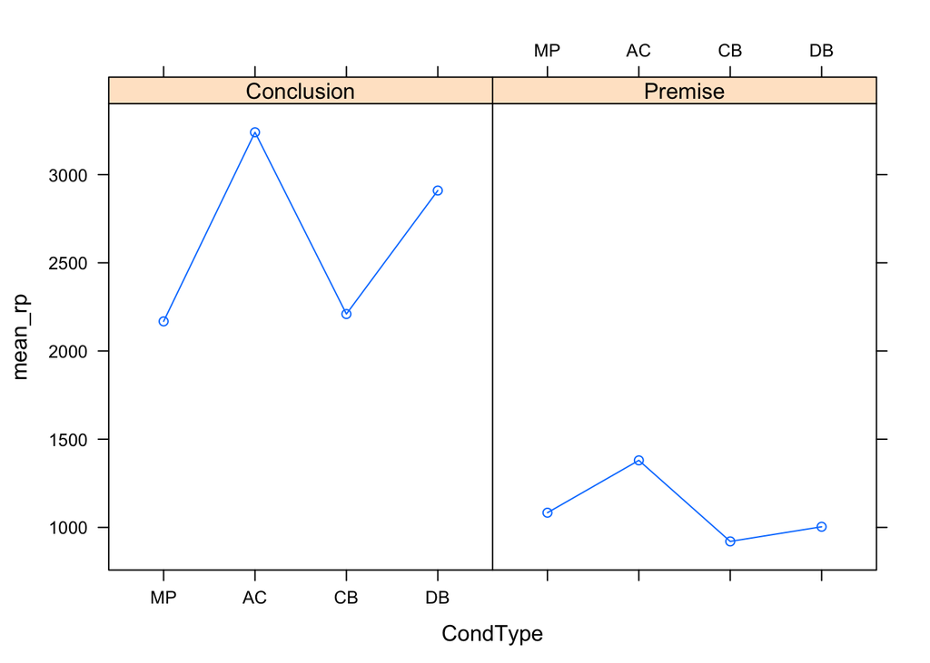

```r
d_rp_a <- d_rp %>%
  gather("dv", "rt", Premise:Conclusion) %>%
  group_by(CondType, dv) %>%
  summarise(mean_rp = mean(rt, na.rm = TRUE))

xyplot(mean_rp ~ CondType|dv, d_rp_a, type = "o")
```

There is an effect on regression path times to the minor premise where it is read more slowly following a conditional than following a (con/dis)junction. There is an effect on regression path time to the conclusion where it is read more slowly in invalid than in valid conditions.

```r
#build the LMM for regression path times on the minor premise
modelrp_premise <- lmer (Premise ~ quasi_validity*major_premise + (1 + quasi_validity*major_premise| P.s)  + (1 + quasi_validity*major_premise| Item), data = d_rp, REML=TRUE)
summary (modelrp_premise)
```

```
## Linear mixed model fit by REML t-tests use Satterthwaite approximations
##   to degrees of freedom [lmerMod]
## Formula: Premise ~ quasi_validity * major_premise + (1 + quasi_validity *
##     major_premise | P.s) + (1 + quasi_validity * major_premise |
##     Item)
##    Data: d_rp
##
## REML criterion at convergence: 10094.3
##
## Scaled residuals:
##     Min      1Q  Median      3Q     Max
## -3.5104 -0.5320 -0.2102  0.2864  4.6834
##
## Random effects:
##  Groups   Name                           Variance Std.Dev. Corr
##  P.s      (Intercept)                     161714   402.1
##           quasi_validity1                 333693   577.7   0.53
##           major_premise1                  292978   541.3   0.97  0.73
##           quasi_validity1:major_premise1 2120611  1456.2   0.38  0.99
##  Item     (Intercept)                      23389   152.9
##           quasi_validity1                  55598   235.8   -0.77
##           major_premise1                   88679   297.8    0.94 -0.95
##           quasi_validity1:major_premise1   65037   255.0   -0.87  0.99
##  Residual                                 665442   815.7
##
##
##
##
##  0.61
##
##
##
##  -0.99
##
## Number of obs: 614, groups:  P.s, 40; Item, 32
##
## Fixed effects:
##                                Estimate Std. Error      df t value
## (Intercept)                     1109.20      76.64   43.12  14.474
## quasi_validity1                 -178.90     120.29   41.38  -1.487
## major_premise1                   289.98     120.35   43.09   2.410
## quasi_validity1:major_premise1  -196.28     269.52   39.87  -0.728
##                                Pr(>|t|)
## (Intercept)                      <2e-16 ***
## quasi_validity1                  0.1445
## major_premise1                   0.0203 *
## quasi_validity1:major_premise1   0.4707
## ---
## Signif. codes:  0 '***' 0.001 '**' 0.01 '*' 0.05 '.' 0.1 ' ' 1
##
## Correlation of Fixed Effects:
##             (Intr) qs_vl1 mjr_p1
## quas_vldty1 0.239
## major_prms1 0.718  0.246
## qs_vldt1:_1 0.214  0.701  0.295
```

```r
#build the LMM for regression path times on the conclusion
modelrp_concl <- lmer (Conclusion ~ quasi_validity*major_premise + (1 + quasi_validity*major_premise| P.s)  + (1 + quasi_validity*major_premise| Item), data = d_rp, REML=TRUE)
summary (modelrp_concl)
```

```
## Linear mixed model fit by REML t-tests use Satterthwaite approximations
##   to degrees of freedom [lmerMod]
## Formula:
## Conclusion ~ quasi_validity * major_premise + (1 + quasi_validity *
##     major_premise | P.s) + (1 + quasi_validity * major_premise |
##     Item)
##    Data: d_rp
##
## REML criterion at convergence: 11367.4
##
## Scaled residuals:
##     Min      1Q  Median      3Q     Max
## -2.3308 -0.4833 -0.2341  0.1769  6.4400
##
## Random effects:
##  Groups   Name                           Variance Std.Dev. Corr
##  P.s      (Intercept)                    1088081  1043.1
##           quasi_validity1                 960349   980.0   -0.89
##           major_premise1                  183104   427.9    0.55 -0.87
##           quasi_validity1:major_premise1 3477710  1864.9   -0.20  0.62
##  Item     (Intercept)                     112946   336.1
##           quasi_validity1                  11459   107.0   -1.00
##           major_premise1                   48823   221.0    0.30 -0.22
##           quasi_validity1:major_premise1  253030   503.0    0.96 -0.98
##  Residual                                6493963  2548.3
##
##
##
##
##  -0.93
##
##
##
##   0.01
##
## Number of obs: 612, groups:  P.s, 40; Item, 32
##
## Fixed effects:
##                                Estimate Std. Error      df t value
## (Intercept)                     2620.15     203.50   40.82  12.875
## quasi_validity1                 -868.77     258.88   51.57  -3.356
## major_premise1                   133.64     220.75   28.49   0.605
## quasi_validity1:major_premise1  -341.39     515.41   35.82  -0.662
##                                Pr(>|t|)
## (Intercept)                    4.44e-16 ***
## quasi_validity1                 0.00149 **
## major_premise1                  0.54970
## quasi_validity1:major_premise1  0.51197
## ---
## Signif. codes:  0 '***' 0.001 '**' 0.01 '*' 0.05 '.' 0.1 ' ' 1
##
## Correlation of Fixed Effects:
##             (Intr) qs_vl1 mjr_p1
## quas_vldty1 -0.456
## major_prms1  0.151 -0.170
## qs_vldt1:_1 -0.047  0.200 -0.170
```

Run the total time analysis. First some data wrangling and setting up the contrasts.

```r
d_tt <- read_csv("~/Desktop/Air Work/R analyses/Reasoning/TT.csv")
d_tt <- add_conditions(d_tt)
attr(d_tt, "spec") <- NULL
str(d_tt)

index <- d_tt$CondType == "MP" | d_tt$CondType == "AC" | d_tt$CondType == "CB"| d_tt$CondType == "DB"
d_tt <- d_tt[index,]

d_tt$P.s <- as.factor (d_tt$P.s)
d_tt$Item <- as.factor (d_tt$Item)

contrasts (d_tt$quasi_validity) <- matrix (c(.5, -.5))
contrasts (d_tt$major_premise) <- matrix (c(.5, -.5))
```

Plot the means for each of the 4 conditions.

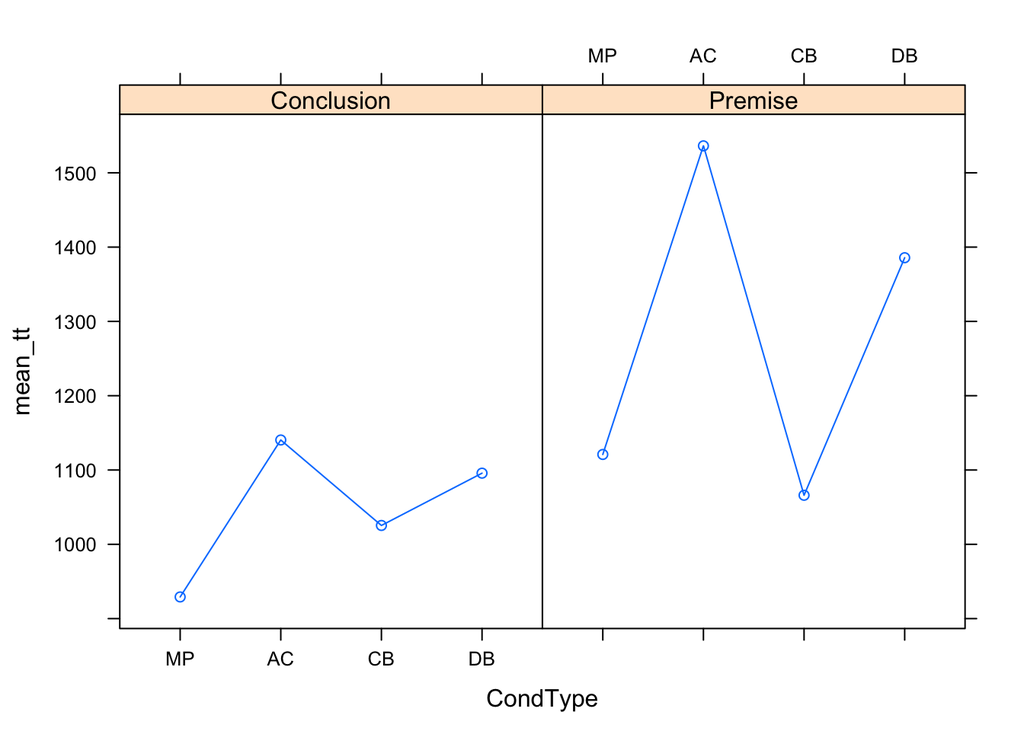

```r
d_tt_a <- d_tt %>%
  gather("dv", "rt", Premise:Conclusion) %>%
  group_by(CondType, dv) %>%
  summarise(mean_tt = mean(rt, na.rm = TRUE))

xyplot(mean_tt ~ CondType|dv, d_tt_a, type = "o")
```

There is an effect on total times to the minor premise where it is read more slowly in invalid than in valid conditions. Nothing on the conclusion.

```r
#build the LMM for total times on the minor premise - note, item random effects need to be simplified for the model to converge
modeltt_premise <- lmer (Premise ~ quasi_validity*major_premise + (1 + quasi_validity*major_premise| P.s)  + (1 + quasi_validity+major_premise| Item), data = d_tt, REML=TRUE)
summary (modeltt_premise)
```

```
## Linear mixed model fit by REML t-tests use Satterthwaite approximations
##   to degrees of freedom [lmerMod]
## Formula: Premise ~ quasi_validity * major_premise + (1 + quasi_validity *
##     major_premise | P.s) + (1 + quasi_validity + major_premise |
##     Item)
##    Data: d_tt
##
## REML criterion at convergence: 10361
##
## Scaled residuals:
##     Min      1Q  Median      3Q     Max
## -1.9524 -0.5558 -0.2227  0.2547  6.3114
##
## Random effects:
##  Groups   Name                           Variance Std.Dev. Corr
##  P.s      (Intercept)                     98324.6 313.57
##           quasi_validity1                 96926.6 311.33   -0.48
##           major_premise1                  31431.9 177.29   -0.02 -0.81
##           quasi_validity1:major_premise1 118887.8 344.80   -0.27  0.94
##  Item     (Intercept)                     12155.6 110.25
##           quasi_validity1                   345.9  18.60   -1.00
##           major_premise1                   4916.6  70.12    1.00 -1.00
##  Residual                                694109.8 833.13
##
##
##
##
##  -0.76
##
##
##
##
## Number of obs: 634, groups:  P.s, 40; Item, 32
##
## Fixed effects:
##                                Estimate Std. Error      df t value
## (Intercept)                     1276.63      62.72   40.17  20.354
## quasi_validity1                 -367.65      82.57   46.90  -4.453
## major_premise1                   101.09      72.95   44.46   1.386
## quasi_validity1:major_premise1   -96.79     143.20   60.40  -0.676
##                                Pr(>|t|)
## (Intercept)                     < 2e-16 ***
## quasi_validity1                5.22e-05 ***
## major_premise1                    0.173
## quasi_validity1:major_premise1    0.502
## ---
## Signif. codes:  0 '***' 0.001 '**' 0.01 '*' 0.05 '.' 0.1 ' ' 1
##
## Correlation of Fixed Effects:
##             (Intr) qs_vl1 mjr_p1
## quas_vldty1 -0.236
## major_prms1  0.049 -0.196
## qs_vldt1:_1 -0.084  0.216 -0.108
```

```r
#build the LMM for total  times on the conclusion
modeltt_concl <- lmer (Conclusion ~ quasi_validity*major_premise + (1 + quasi_validity*major_premise| P.s)  + (1 + quasi_validity*major_premise| Item), data = d_tt, REML=TRUE)
summary (modeltt_concl)
```

```
## Linear mixed model fit by REML t-tests use Satterthwaite approximations
##   to degrees of freedom [lmerMod]
## Formula:
## Conclusion ~ quasi_validity * major_premise + (1 + quasi_validity *
##     major_premise | P.s) + (1 + quasi_validity * major_premise |
##     Item)
##    Data: d_tt
##
## REML criterion at convergence: 10170.3
##
## Scaled residuals:
##     Min      1Q  Median      3Q     Max
## -1.5887 -0.5120 -0.2341  0.2189  9.8483
##
## Random effects:
##  Groups   Name                           Variance Std.Dev. Corr
##  P.s      (Intercept)                     96067   309.95
##           quasi_validity1                 34395   185.46   -0.60
##           major_premise1                  77874   279.06   -0.67 -0.17
##           quasi_validity1:major_premise1 127124   356.54   -0.39  0.92
##  Item     (Intercept)                      7888    88.82
##           quasi_validity1                 12013   109.60   -0.73
##           major_premise1                  20165   142.00   -0.59 -0.12
##           quasi_validity1:major_premise1  26884   163.96    0.44 -0.93
##  Residual                                789616   888.60
##
##
##
##
##  -0.42
##
##
##
##   0.47
##
## Number of obs: 618, groups:  P.s, 40; Item, 32
##
## Fixed effects:
##                                Estimate Std. Error      df t value
## (Intercept)                     1040.74      62.71   38.83  16.597
## quasi_validity1                 -138.33      79.78   34.96  -1.734
## major_premise1                   -23.53      87.77   33.78  -0.268
## quasi_validity1:major_premise1  -133.61     156.67   43.52  -0.853
##                                Pr(>|t|)
## (Intercept)                      <2e-16 ***
## quasi_validity1                  0.0918 .
## major_premise1                   0.7903
## quasi_validity1:major_premise1   0.3984
## ---
## Signif. codes:  0 '***' 0.001 '**' 0.01 '*' 0.05 '.' 0.1 ' ' 1
##
## Correlation of Fixed Effects:
##             (Intr) qs_vl1 mjr_p1
## quas_vldty1 -0.224
## major_prms1 -0.304 -0.046
## qs_vldt1:_1 -0.094  0.080 -0.059
```